# tables.supplement

Devon DeRaad

3/27/2019

```r
library(ggbiplot)
library(ggridges)
library(grid)
library(gridExtra)
library(plotrix)
```

Bring in morphological data

```r
#bring in data
scrubspecmorph<-read.csv("~/Dropbox/scrub poster/manuscript/scrubspecmorph.csv")
head(scrubspecmorph)
```

```
##      id museum    sex  locality           subspecies      lat       long
## 1 18334    psm   male   contact sumichrasti/cyanotis 19.04498  -98.20233
## 2 19180    mlz female woodhouse               grisea 26.74261 -106.05285
## 3 19192    MLZ   male woodhouse               grisea 26.74261 -106.05285
## 4 19196    mlz female woodhouse               grisea 26.74261 -106.05285
## 5 19197    MLZ   male woodhouse               grisea 26.74261 -106.05285
## 6 19201    mlz   male woodhouse               grisea 26.74261 -106.05285
##    wing  tail tarsus   bl  bw  bd   S1.blue    S1.red
## 1 138.5 161.0   38.9 19.4 8.7 9.7 0.2307985 0.3548928
## 2 128.0 141.6   38.1 17.3 7.2 7.8 0.2864534 0.2474419
## 3 136.5 152.0   38.8 18.9 7.7 8.8 0.2898149 0.2429218
## 4 135.0 148.0   38.1 16.5 7.6 8.3 0.2778012 0.2504546
## 5 137.0 148.0   39.1 18.6 7.8 8.7 0.2883707 0.2444771
## 6 125.5 140.0   37.8 16.8 6.5 7.8 0.2900892 0.2389913
```

Create histograms to visualize normality of each variable

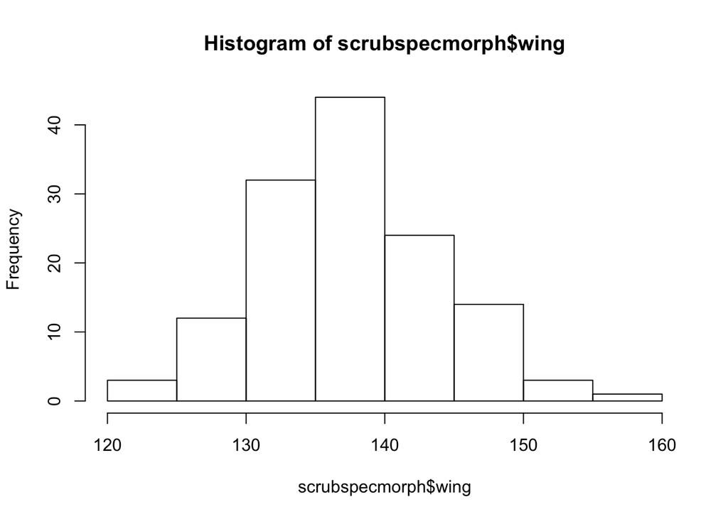

```r
###start analyzing morph
##normalitycheck
hist(scrubspecmorph$wing)
```

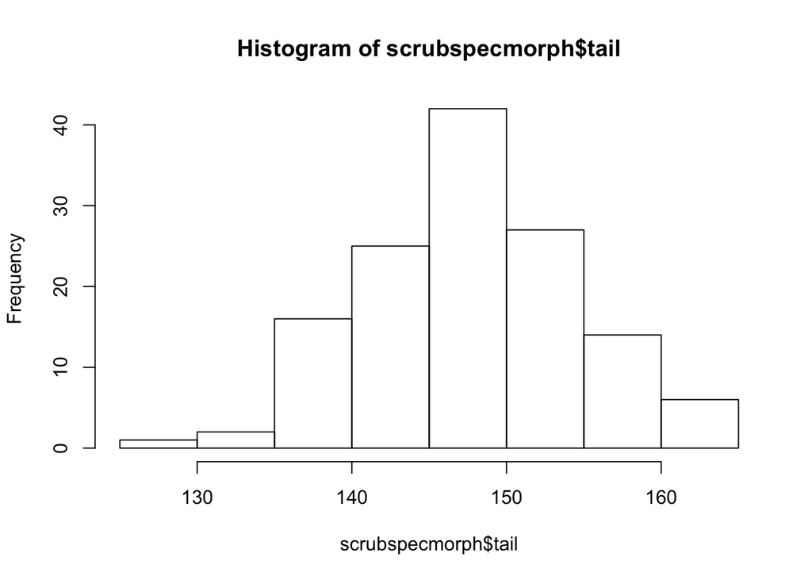

```r
hist(scrubspecmorph$tail)
```

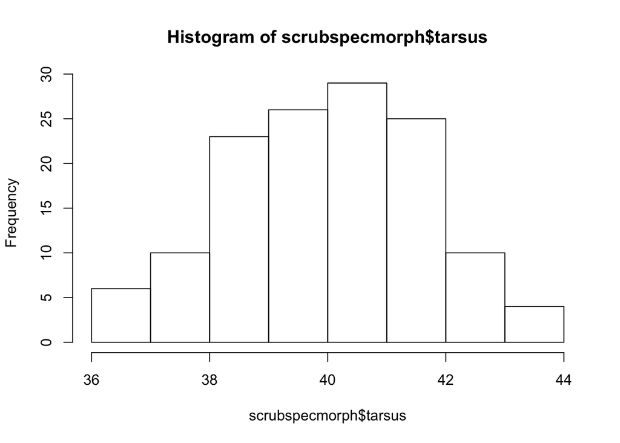

```r
hist(scrubspecmorph$tarsus)
```

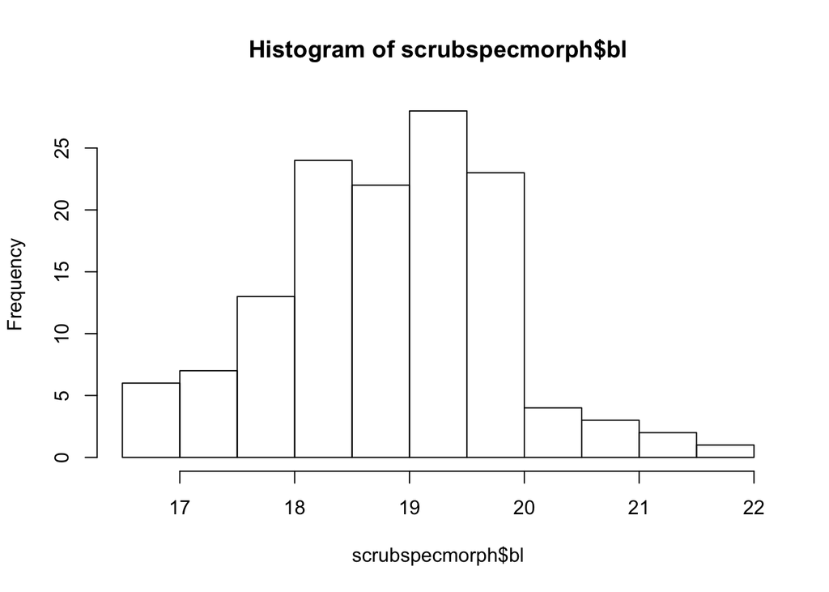

```r
hist(scrubspecmorph$bl)
```

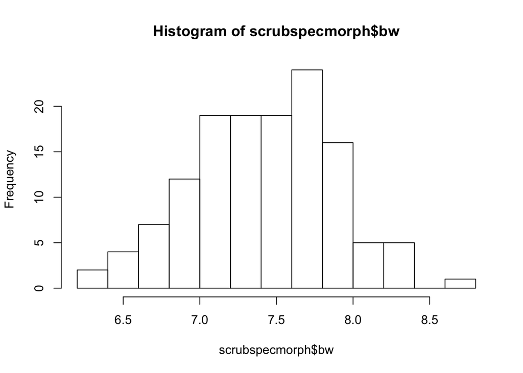

```r
hist(scrubspecmorph$bw)
```

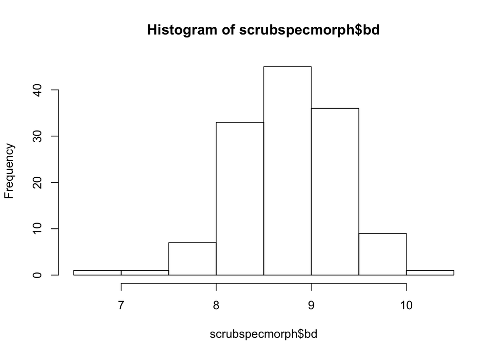

```r
hist(scrubspecmorph$bd)
```

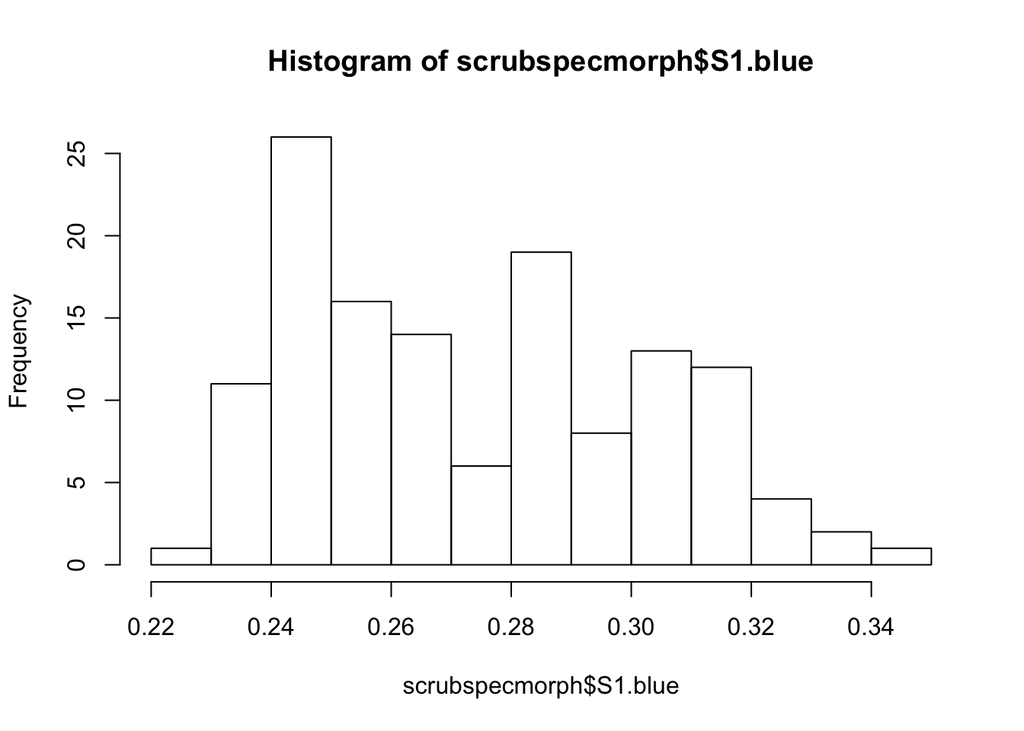

```r
hist(scrubspecmorph$S1.blue)
```

```r
#visually verified normality in the distribution of each trait
```

Subset our samples by multiple categories

```r
#subset by sex
malescrub<- subset(scrubspecmorph, scrubspecmorph$sex=="male")
femalescrub<-subset(scrubspecmorph, scrubspecmorph$sex=="female")

#subset by group
woodhousesgroup<- subset(scrubspecmorph, scrubspecmorph$locality=="woodhouse")
sumichrastsgroup<-subset(scrubspecmorph, scrubspecmorph$locality=="sumichrasti")

#subset by subspecies
gris<- subset(scrubspecmorph, scrubspecmorph$subspecies=="grisea")
cyanotis<- subset(scrubspecmorph, scrubspecmorph$subspecies=="cyanotis")
hyb<- subset(scrubspecmorph, scrubspecmorph$subspecies=="sumichrasti/cyanotis")
sumi<- subset(scrubspecmorph, scrubspecmorph$subspecies=="sumichrasti")
remota<- subset(scrubspecmorph, scrubspecmorph$subspecies=="remota")
```

Calculate standard error for each measurement (Table 1) and (Table S1)

```r
std.error(malescrub$wing)
```

```
## [1] 0.7316163
```

```r
std.error(malescrub$tail)
```

```
## [1] 0.7416087
```

```r
std.error(malescrub$tarsus)
```

```
## [1] 0.1897403
```

```r
std.error(malescrub$bl)
```

```
## [1] 0.09595281
```

```r
std.error(malescrub$bw)
```

```
## [1] 0.04993823
```

```r
std.error(malescrub$bd)
```

```
## [1] 0.05408056
```

```r
std.error(malescrub$S1.blue)
```

```
## [1] 0.003256758
```

```r
std.error(femalescrub$wing)
```

```
## [1] 0.836287
```

```r
std.error(femalescrub$tail)
```

```
## [1] 0.7464317
```

```r
std.error(femalescrub$tarsus)
```

```
## [1] 0.2161017
```

```r
std.error(femalescrub$bl)
```

```
## [1] 0.1290711
```

```r
std.error(femalescrub$bw)
```

```
## [1] 0.06105283
```

```r
std.error(femalescrub$bd)
```

```
## [1] 0.0741482
```

```r
std.error(femalescrub$S1.blue)
```

```
## [1] 0.003868808
```

```r
std.error(woodhousesgroup$wing)
```

```
## [1] 0.6610908
```

```r
std.error(woodhousesgroup$tail)
```

```
## [1] 0.7972925
```

```r
std.error(woodhousesgroup$tarsus)
```

```
## [1] 0.2056446
```

```r
std.error(woodhousesgroup$bl)
```

```
## [1] 0.1423931
```

```r
std.error(woodhousesgroup$bw)
```

```
## [1] 0.0542068
```

```r
std.error(woodhousesgroup$bd)
```

```
## [1] 0.06517845
```

```r
std.error(woodhousesgroup$S1.blue)
```

```
## [1] 0.002259295
```

```r
std.error(sumichrastsgroup$wing)
```

```
## [1] 0.8267477
```

```r
std.error(sumichrastsgroup$tail)
```

```
## [1] 0.8928648
```

```r
std.error(sumichrastsgroup$tarsus)
```

```
## [1] 0.2063197
```

```r
std.error(sumichrastsgroup$bl)
```

```
## [1] 0.1310318
```

```r
std.error(sumichrastsgroup$bw)
```

```
## [1] 0.0606046
```

```r
std.error(sumichrastsgroup$bd)
```

```
## [1] 0.06331053
```

```r
std.error(sumichrastsgroup$S1.blue)
```

```
## [1] 0.001514935
```

```r
std.error(gris$wing)
```

```
## [1] 1.25128
```

```r
std.error(gris$tail)
```

```
## [1] 1.543448
```

```r
std.error(gris$tarsus)
```

```
## [1] 0.3864438
```

```r
std.error(gris$bl)
```

```
## [1] 0.3744969
```

```r
std.error(gris$bw)
```

```
## [1] 0.1321157
```

```r
std.error(gris$bd)
```

```
## [1] 0.1453977
```

```r
std.error(gris$S1.blue)
```

```
## [1] 0.00237668
```

```r
std.error(cyanotis$wing)
```

```
## [1] 0.7549946
```

```r
std.error(cyanotis$tail)
```

```
## [1] 0.9199719
```

```r
std.error(cyanotis$tarsus)
```

```
## [1] 0.2270761
```

```r
std.error(cyanotis$bl)
```

```
## [1] 0.1438204
```

```r
std.error(cyanotis$bw)
```

```
## [1] 0.05951654
```

```r
std.error(cyanotis$bd)
```

```
## [1] 0.07351484
```

```r
std.error(cyanotis$S1.blue)
```

```
## [1] 0.002511561
```

```r
std.error(hyb$wing)
```

```
## [1] 0.8925411
```

```r
std.error(hyb$tail)
```

```
## [1] 1.651715
```

```r
std.error(hyb$tarsus)
```

```
## [1] 0.3392667
```

```r
std.error(hyb$bl)
```

```
## [1] 0.2020259
```

```r
std.error(hyb$bw)
```

```
## [1] 0.1058915
```

```r
std.error(hyb$bd)
```

```
## [1] 0.1010214
```

```r
std.error(hyb$S1.blue)
```

```
## [1] 0.004797035
```

```r
std.error(sumi$wing)
```

```
## [1] 1.041713
```

```r
std.error(sumi$tail)
```

```
## [1] 1.110884
```

```r
std.error(sumi$tarsus)
```

```
## [1] 0.2212134
```

```r
std.error(sumi$bl)
```

```
## [1] 0.1456232
```

```r
std.error(sumi$bw)
```

```
## [1] 0.07226328
```

```r
std.error(sumi$bd)
```

```
## [1] 0.07623113
```

```r
std.error(sumi$S1.blue)
```

```
## [1] 0.001811648
```

```r
std.error(remota$wing)
```

```
## [1] 1.038363
```

```r
std.error(remota$tail)
```

```
## [1] 1.137289
```

```r
std.error(remota$tarsus)
```

```
## [1] 0.4527649
```

```r
std.error(remota$bl)
```

```
## [1] 0.2800818
```

```r
std.error(remota$bw)
```

```
## [1] 0.1040959
```

```r
std.error(remota$bd)
```

```
## [1] 0.1151921
```

```r
std.error(remota$S1.blue)
```

```
## [1] 0.002835557
```

Conduct T-tests between males and females in each character.

```r
#t.test for differences in each trait between sexes
t.test(malescrub$wing, femalescrub$wing)
```

```
##
##  Welch Two Sample t-test
##
## data:  malescrub$wing and femalescrub$wing
## t = 2.9413, df = 115.72, p-value = 0.003949
## alternative hypothesis: true difference in means is not equal to 0
## 95 percent confidence interval:
##  1.067349 5.468976
## sample estimates:
## mean of x mean of y
##  139.2778  136.0096
```

```r
t.test(malescrub$tail, femalescrub$tail)
```

```
##
##  Welch Two Sample t-test
##
## data:  malescrub$tail and femalescrub$tail
## t = 5.6291, df = 124.22, p-value = 1.145e-07
## alternative hypothesis: true difference in means is not equal to 0
## 95 percent confidence interval:
##  3.840402 8.005562
## sample estimates:
## mean of x mean of y
##  150.3691  144.4462
```

```r
t.test(malescrub$tarsus, femalescrub$tarsus)
```

```
##
##  Welch Two Sample t-test
##
## data:  malescrub$tarsus and femalescrub$tarsus
## t = 2.2273, df = 116, p-value = 0.02786
## alternative hypothesis: true difference in means is not equal to 0
## 95 percent confidence interval:
##  0.07094161 1.21011252
## sample estimates:
## mean of x mean of y
##  40.29630  39.65577
```

```r
t.test(malescrub$bl, femalescrub$bl)
```

```
##
##  Welch Two Sample t-test
##
## data:  malescrub$bl and femalescrub$bl
## t = 6.4181, df = 102.91, p-value = 4.3e-09
## alternative hypothesis: true difference in means is not equal to 0
## 95 percent confidence interval:
##  0.7132458 1.3511891
## sample estimates:
## mean of x mean of y
##  19.24568  18.21346
```

```r
t.test(malescrub$bw, femalescrub$bw)
```

```
##
##  Welch Two Sample t-test
##
## data:  malescrub$bw and femalescrub$bw
## t = 3.1181, df = 110.53, p-value = 0.002321
## alternative hypothesis: true difference in means is not equal to 0
## 95 percent confidence interval:
##  0.08963665 0.40224369
## sample estimates:
## mean of x mean of y
##  7.555556  7.309615
```

```r
t.test(malescrub$bd, femalescrub$bd)
```

```
##
##  Welch Two Sample t-test
##
## data:  malescrub$bd and femalescrub$bd
## t = 4.649, df = 101.4, p-value = 1.007e-05
## alternative hypothesis: true difference in means is not equal to 0
## 95 percent confidence interval:
##  0.2446136 0.6087103
## sample estimates:
## mean of x mean of y
##  8.990123  8.563462
```

```r
t.test(malescrub$S1.blue, femalescrub$S1.blue)
```

```
##
##  Welch Two Sample t-test
##
## data:  malescrub$S1.blue and femalescrub$S1.blue
## t = 0.79554, df = 112.78, p-value = 0.428
## alternative hypothesis: true difference in means is not equal to 0
## 95 percent confidence interval:
##  -0.00599612  0.01404230
## sample estimates:
## mean of x mean of y
## 0.2754770 0.2714539
```

```r
#everything but back color is significantly different
```

Separate by group, and use pairwise t-tests for differences between groups.

```r
#subset
sumgroup<- subset(scrubspecmorph, locality == "sumichrasti")
woodgroup<- subset(scrubspecmorph, locality == "woodhouse")
contactintermediateintrogressedhybridgroup<- subset(scrubspecmorph, locality == "contact")

#t.test for differences in each trait between groups
t.test(sumgroup$wing, woodgroup$wing)
```

```
##
##  Welch Two Sample t-test
##
## data:  sumgroup$wing and woodgroup$wing
## t = 8.0868, df = 99.881, p-value = 1.488e-12
## alternative hypothesis: true difference in means is not equal to 0
## 95 percent confidence interval:
##   6.460205 10.660578
## sample estimates:
## mean of x mean of y
##  142.2885  133.7281
```

```r
t.test(sumgroup$tail, woodgroup$tail)
```

```
##
##  Welch Two Sample t-test
##
## data:  sumgroup$tail and woodgroup$tail
## t = 3.5935, df = 104.34, p-value = 0.0004997
## alternative hypothesis: true difference in means is not equal to 0
## 95 percent confidence interval:
##  1.927852 6.675184
## sample estimates:
## mean of x mean of y
##  150.3173  146.0158
```

```r
t.test(sumgroup$tarsus, woodgroup$tarsus)
```

```
##
##  Welch Two Sample t-test
##
## data:  sumgroup$tarsus and woodgroup$tarsus
## t = 4.8476, df = 106.73, p-value = 4.267e-06
## alternative hypothesis: true difference in means is not equal to 0
## 95 percent confidence interval:
##  0.834621 1.989603
## sample estimates:
## mean of x mean of y
##  40.69808  39.28596
```

```r
t.test(sumgroup$bl, woodgroup$bl)
```

```
##
##  Welch Two Sample t-test
##
## data:  sumgroup$bl and woodgroup$bl
## t = 0.86652, df = 106.86, p-value = 0.3881
## alternative hypothesis: true difference in means is not equal to 0
## 95 percent confidence interval:
##  -0.2159329  0.5512905
## sample estimates:
## mean of x mean of y
##  19.01154  18.84386
```

```r
t.test(sumgroup$bw, woodgroup$bw)
```

```
##
##  Welch Two Sample t-test
##
## data:  sumgroup$bw and woodgroup$bw
## t = 3.5672, df = 104.39, p-value = 0.0005464
## alternative hypothesis: true difference in means is not equal to 0
## 95 percent confidence interval:
##  0.1288139 0.4512806
## sample estimates:
## mean of x mean of y
##  7.586538  7.296491
```

```r
t.test(sumgroup$bd, woodgroup$bd)
```

```
##
##  Welch Two Sample t-test
##
## data:  sumgroup$bd and woodgroup$bd
## t = 6.3734, df = 106.97, p-value = 4.782e-09
## alternative hypothesis: true difference in means is not equal to 0
## 95 percent confidence interval:
##  0.3989861 0.7592460
## sample estimates:
## mean of x mean of y
##  9.101923  8.522807
```

```r
t.test(sumgroup$S1.blue, woodgroup$S1.blue)
```

```
##
##  Welch Two Sample t-test
##
## data:  sumgroup$S1.blue and woodgroup$S1.blue
## t = -18.563, df = 96.301, p-value < 2.2e-16
## alternative hypothesis: true difference in means is not equal to 0
## 95 percent confidence interval:
##  -0.05589511 -0.04509647
## sample estimates:
## mean of x mean of y
## 0.2502330 0.3007288
```

Plot to see if there is a correlation between back color and body size

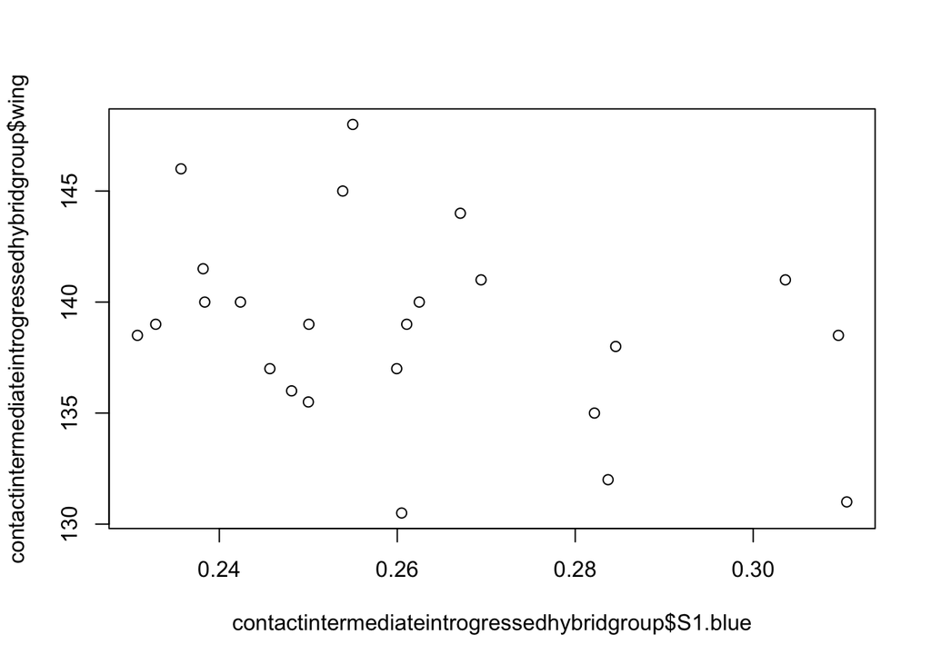

```r
#data vis to see if size and back color are corresponding
plot(contactintermediateintrogressedhybridgroup$wing ~contactintermediateintrogressedhybridgroup$S1.blue)
```

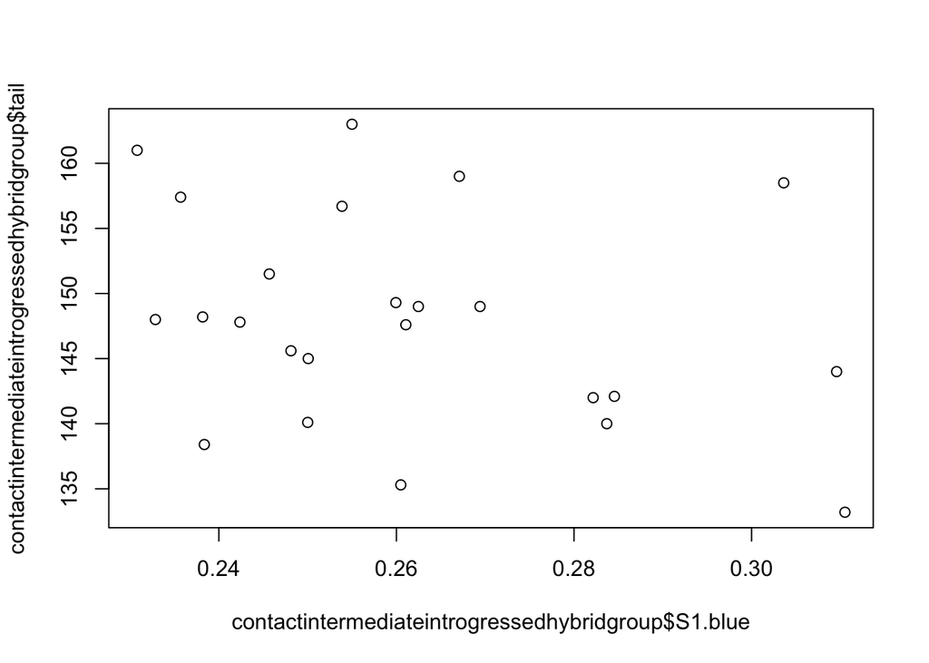

```r
plot(contactintermediateintrogressedhybridgroup$tail ~contactintermediateintrogressedhybridgroup$S1.blue)
```

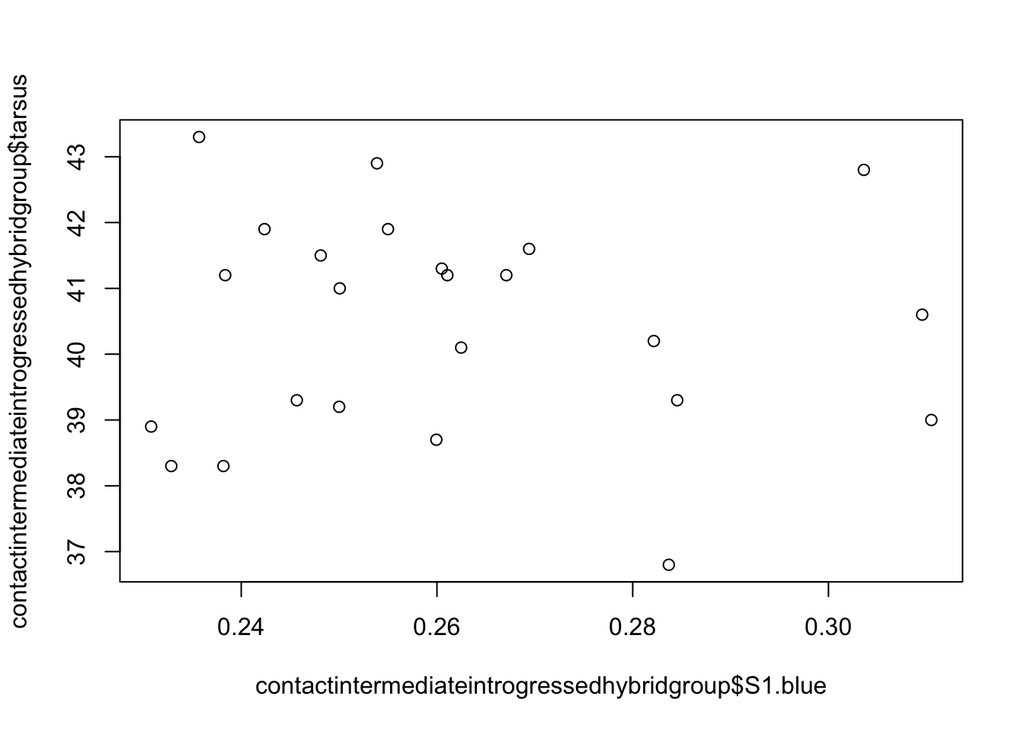

```r
plot(contactintermediateintrogressedhybridgroup$tarsus ~contactintermediateintrogressedhybridgroup$S1.blue)
```

```r
#looks pretty interesting, try for PC1/S1B
```

I want to use PC1 as a proxy for general body size, so this chunk will make a PCA from our morphological data, extract the values of the first few PC axes, and paste them into our dataset as columns as though it is just another characteristic.

```r
#build PCAscrubspecmorph
pca.scruball <- princomp(scrubspecmorph[,8:14], cor=TRUE)
#view loadings by variable
unclass(pca.scruball$loadings)
```

```
##             Comp.1      Comp.2      Comp.3      Comp.4      Comp.5
## wing     0.4633632  0.19945991  0.27294790  0.22938513  0.13557958
## tail     0.4153102 -0.10267070  0.39993461  0.60705860 -0.05503053
## tarsus   0.3915982  0.06471396  0.33071829 -0.65438235  0.48442886
## bl       0.3164987 -0.61388721  0.03348982 -0.29837207 -0.47882936
## bw       0.3334493 -0.17526889 -0.70571601  0.19253093  0.50068508
## bd       0.4253020 -0.02913543 -0.34105412 -0.09159202 -0.34312376
## S1.blue -0.2592707 -0.73284447  0.20174886  0.12713342  0.38238917
##               Comp.6        Comp.7
## wing     0.039742048  0.7735832088
## tail     0.009008839 -0.5342273243
## tarsus  -0.071498463 -0.2551250440
## bl       0.438345985  0.1067653828
## bw       0.261215277 -0.0637978419
## bd      -0.758833348 -0.0006203457
## S1.blue -0.396255860  0.1887114214
```

```r
#create dataframe of PC scores
pcascoresbyindiv<-data.frame(pca.scruball$scores)
#insert id column from scrubspecmorph into pcascorebyindiv
pcascoresbyindiv$id <- scrubspecmorph$id
#merge datasets to add PC scores to scrubspecmorph
PCAscrubspecmorph<-merge(scrubspecmorph, pcascoresbyindiv, by = "id")
head(PCAscrubspecmorph)
```

```
##      id museum    sex  locality           subspecies      lat       long
## 1 18334    psm   male   contact sumichrasti/cyanotis 19.04498  -98.20233
## 2 19180    mlz female woodhouse               grisea 26.74261 -106.05285
## 3 19192    MLZ   male woodhouse               grisea 26.74261 -106.05285
## 4 19196    mlz female woodhouse               grisea 26.74261 -106.05285
## 5 19197    MLZ   male woodhouse               grisea 26.74261 -106.05285
## 6 19201    mlz   male woodhouse               grisea 26.74261 -106.05285
##    wing  tail tarsus   bl  bw  bd   S1.blue    S1.red     Comp.1
## 1 138.5 161.0   38.9 19.4 8.7 9.7 0.2307985 0.3548928  2.7093513
## 2 128.0 141.6   38.1 17.3 7.2 7.8 0.2864534 0.2474419 -3.1438981
## 3 136.5 152.0   38.8 18.9 7.7 8.8 0.2898149 0.2429218 -0.1273813
## 4 135.0 148.0   38.1 16.5 7.6 8.3 0.2778012 0.2504546 -1.7444138
## 5 137.0 148.0   39.1 18.6 7.8 8.7 0.2883707 0.2444771 -0.3514860
## 6 125.5 140.0   37.8 16.8 6.5 7.8 0.2900892 0.2389913 -4.1871707
##        Comp.2     Comp.3    Comp.4      Comp.5      Comp.6      Comp.7
## 1  0.02123296 -2.1899981 1.6406742 -0.46438003  0.38948031 -1.18167296
## 2  0.47965354 -0.1045860 0.4073618  0.53571944  0.45633253 -0.42306992
## 3 -0.68685037 -0.3193044 0.9468791  0.03789025  0.02375313 -0.21977116
## 4  1.12174965 -0.4521200 1.5046635  1.01159930 -0.18766426 -0.29304712
## 5 -0.41435683 -0.5853505 0.6301926  0.46202174  0.09591630  0.05300395
## 6  0.89200710  0.7238423 0.1632352 -0.07081998 -0.21278142 -0.47904828
```

Subset, and plot the relationship between general body size (PC1) and back color within the hybrid zone for both males and females, and together.

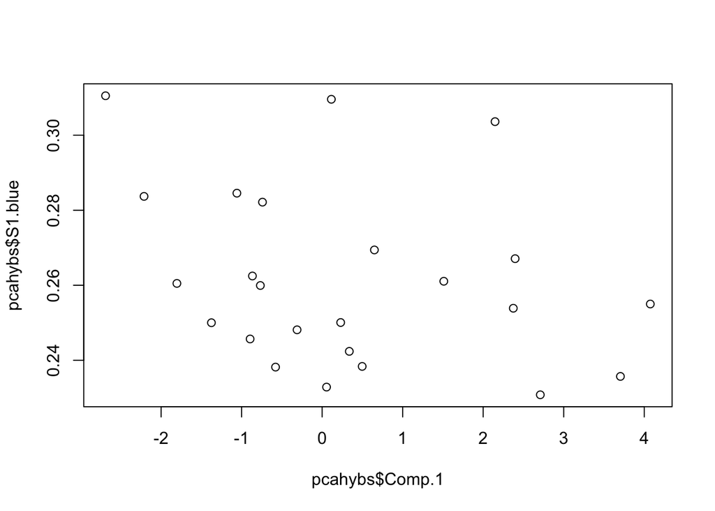

```r
#subset
pcahybs<- subset(PCAscrubspecmorph, locality == "contact")
malepcahybs<- subset(pcahybs, sex == "male")
femalepcahybs<- subset(pcahybs, sex == "female")

#plot
plot(pcahybs$S1.blue ~ pcahybs$Comp.1)
```

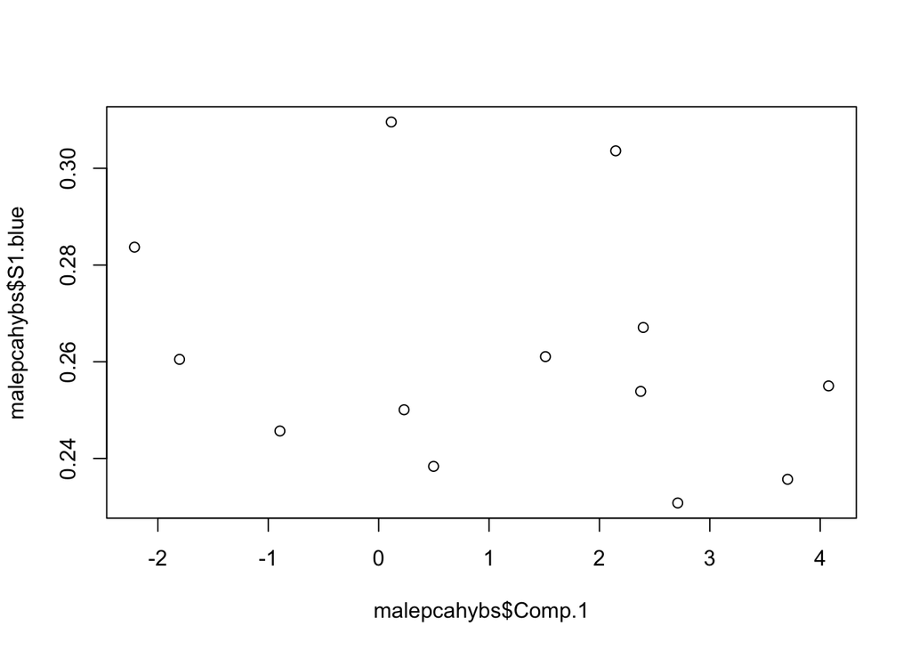

```r
plot(malepcahybs$S1.blue ~ malepcahybs$Comp.1)
```

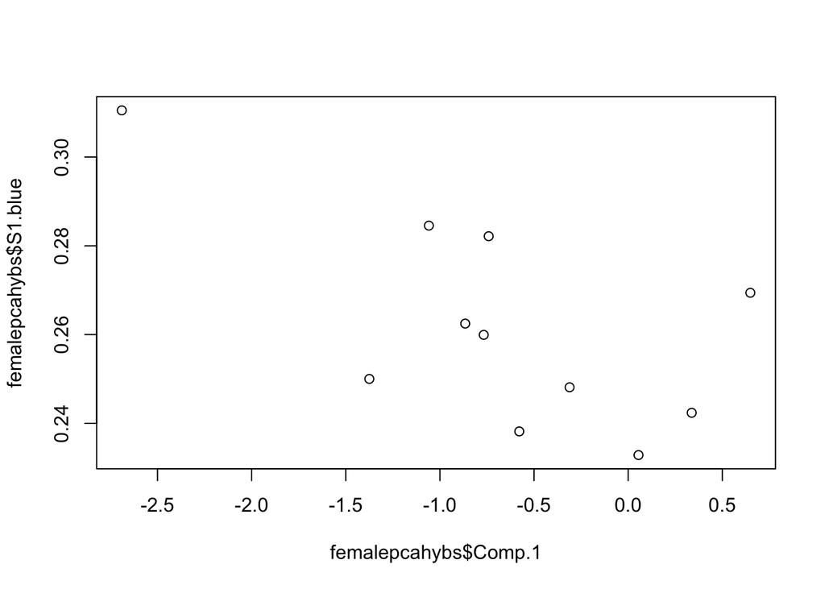

```r
plot(femalepcahybs$S1.blue ~ femalepcahybs$Comp.1)
```

Do a linear regression and ggplot that same data

```r
#simple regression
mod<-lm(Comp.1 ~ S1.blue, data = pcahybs)
summary(mod)
```

```
##
## Call:
## lm(formula = Comp.1 ~ S1.blue, data = pcahybs)
##
## Residuals:
##     Min      1Q  Median      3Q     Max
## -2.1399 -1.2276 -0.4957  1.3076  3.6084
##
## Coefficients:
##             Estimate Std. Error t value Pr(>|t|)
## (Intercept)    6.539      4.117   1.588    0.127
## S1.blue      -23.810     15.686  -1.518    0.143
##
## Residual standard error: 1.768 on 22 degrees of freedom
## Multiple R-squared:  0.0948, Adjusted R-squared:  0.05366
## F-statistic: 2.304 on 1 and 22 DF,  p-value: 0.1433
```

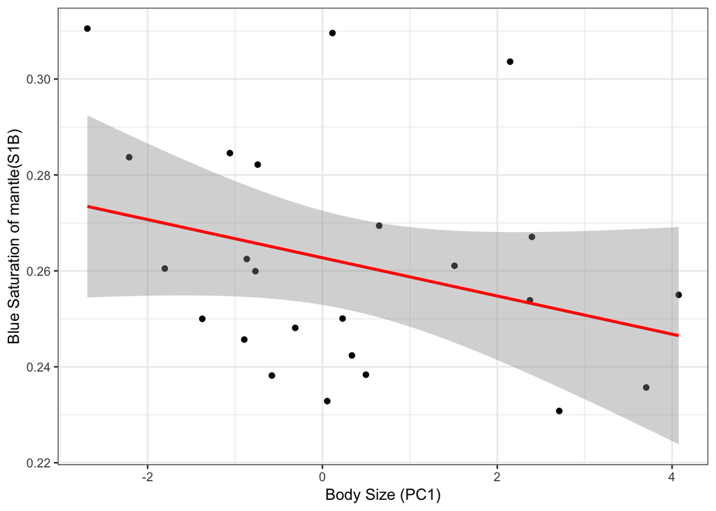

```r
ggplot(pcahybs, aes(x = Comp.1, y = S1.blue)) +
  geom_point() +
  stat_smooth(method = "lm", col = "red")+
  labs(x= "Body Size (PC1)", y= "Blue Saturation of mantle(S1B)")+
  theme_bw()
```

#Supplementary Figure 2

Visualize sex differences on a PCA

```r
#create PCA by sex for only body size
pca.morph<- princomp(scrubspecmorph[, 8:13], cor=TRUE)
#PrintPCA
print(pca.morph)
```

```
## Call:
## princomp(x = scrubspecmorph[, 8:13], cor = TRUE)
##
## Standard deviations:
##    Comp.1    Comp.2    Comp.3    Comp.4    Comp.5    Comp.6
## 1.7938497 0.9206043 0.8297589 0.7538062 0.6692769 0.4795164
##
##  6  variables and  133 observations.
```

```r
#summarize PC's
summary(pca.morph)
```

```
## Importance of components:
##                           Comp.1    Comp.2    Comp.3     Comp.4     Comp.5
## Standard deviation     1.7938497 0.9206043 0.8297589 0.75380616 0.66927687
## Proportion of Variance 0.5363161 0.1412521 0.1147500 0.09470395 0.07465526
## Cumulative Proportion  0.5363161 0.6775682 0.7923181 0.88702209 0.96167734
##                            Comp.6
## Standard deviation     0.47951635
## Proportion of Variance 0.03832266
## Cumulative Proportion  1.00000000
```

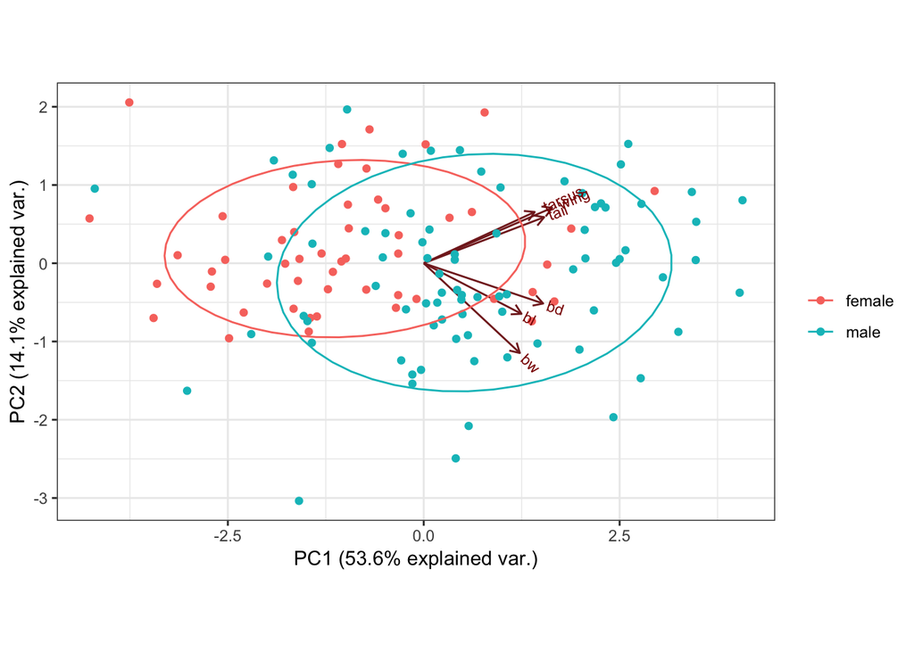

```r
#visualize the differences between sexes
ggbiplot(pca.morph, obs.scale = 1, var.scale = 1,
         groups = scrubspecmorph$sex, ellipse = TRUE) +
  scale_color_discrete(name = '') +
  theme_bw()
```

```r
#save as PDF 7"x7"
```

This chunk will use ggridges to visualize morphological differences between the groups in each character. They are also separated by sex.

```r
#use gg_ridges package to visualize differences in general body size and mantle color
##plot male wing length
malewing<-ggplot(malescrub, aes(x = wing, y = locality, fill = locality, color = locality)) +
  geom_density_ridges(jittered_points = TRUE, position = "raincloud", alpha = .4) +
  scale_color_manual(values = c("green4", "navyblue", "darkred"), aesthetics = c("color", "fill")) +
  labs(x = "male wing length", y = "Group") +
  scale_y_discrete(limits=c("sumichrasti", "contact", "woodhouse"), labels=c("sumichrast's", "contact", "woodhouse's")) +
  theme_classic() +
  theme(legend.position = "none")

#plot female wing length
femwing<-ggplot(femalescrub, aes(x = wing, y = locality, fill = locality, color = locality)) +
  geom_density_ridges(jittered_points = TRUE, position = "raincloud", alpha = .4) +
  scale_color_manual(values = c("green4", "navyblue", "darkred"), aesthetics = c("color", "fill")) +
  labs(x = "female wing length", y = "Group") +
  scale_y_discrete(limits=c("sumichrasti", "contact", "woodhouse"), labels=c("sumichrast's", "contact", "woodhouse's")) +
  theme_classic() +
  theme(legend.position = "none")

##plot male tarsus length
maletars<-ggplot(malescrub, aes(x = tarsus, y = locality, fill = locality, color = locality)) +
  geom_density_ridges(jittered_points = TRUE, position = "raincloud", alpha = .4) +
  scale_color_manual(values = c("green4", "navyblue", "darkred"), aesthetics = c("color", "fill")) +
  labs(x = "male tarsus length", y = "") +
  scale_y_discrete(limits=c("sumichrasti", "contact", "woodhouse"), labels=c()) +
  theme_classic() +
  theme(legend.position = "none")

#plot female tarsus length
femtars<-ggplot(femalescrub, aes(x = tarsus, y = locality, fill = locality, color = locality)) +
  geom_density_ridges(jittered_points = TRUE, position = "raincloud", alpha = .4) +
  scale_color_manual(values = c("green4", "navyblue", "darkred"), aesthetics = c("color", "fill")) +
  labs(x = "female tarsus length", y = "") +
  scale_y_discrete(limits=c("sumichrasti", "contact", "woodhouse"), labels=c()) +
  theme_classic() +
  theme(legend.position = "none")

##plot male tail length
maletail<-ggplot(malescrub, aes(x = tail, y = locality, fill = locality, color = locality)) +
  geom_density_ridges(jittered_points = TRUE, position = "raincloud", alpha = .4) +
  scale_color_manual(values = c("green4", "navyblue", "darkred"), aesthetics = c("color", "fill")) +
  labs(x = "male tail length", y = "") +
  scale_y_discrete(limits=c("sumichrasti", "contact", "woodhouse"), labels=c()) +
  theme_classic() +
  theme(legend.position = "none")

#plot female tail length
femtail<-ggplot(femalescrub, aes(x = tail, y = locality, fill = locality, color = locality)) +
  geom_density_ridges(jittered_points = TRUE, position = "raincloud", alpha = .4) +
  scale_color_manual(values = c("green4", "navyblue", "darkred"), aesthetics = c("color", "fill")) +
  labs(x = "female tail length", y = "") +
  scale_y_discrete(limits=c("sumichrasti", "contact", "woodhouse"), labels=c()) +
  theme_classic() +
  theme(legend.position = "none")

##plot male bill length
malebl<-ggplot(malescrub, aes(x = bl, y = locality, fill = locality, color = locality)) +
  geom_density_ridges(jittered_points = TRUE, position = "raincloud", alpha = .4) +
  scale_color_manual(values = c("green4", "navyblue", "darkred"), aesthetics = c("color", "fill")) +
  labs(x = "male bill length", y = "Group") +
  scale_y_discrete(limits=c("sumichrasti", "contact", "woodhouse"), labels=c("sumichrast's", "contact", "woodhouse's")) +
  theme_classic() +
  theme(legend.position = "none")

#plot female bill length
fembl<-ggplot(femalescrub, aes(x = bl, y = locality, fill = locality, color = locality)) +
  geom_density_ridges(jittered_points = TRUE, position = "raincloud", alpha = .4) +
  scale_color_manual(values = c("green4", "navyblue", "darkred"), aesthetics = c("color", "fill")) +
  labs(x = "female bill length", y = "Group") +
  scale_y_discrete(limits=c("sumichrasti", "contact", "woodhouse"), labels=c("sumichrast's", "contact", "woodhouse's")) +
  theme_classic() +
  theme(legend.position = "none")

##plot male bill width
malebw<-ggplot(malescrub, aes(x = bw, y = locality, fill = locality, color = locality)) +
  geom_density_ridges(jittered_points = TRUE, position = "raincloud", alpha = .4) +
  scale_color_manual(values = c("green4", "navyblue", "darkred"), aesthetics = c("color", "fill")) +
  labs(x = "male bill width", y = "") +
  scale_y_discrete(limits=c("sumichrasti", "contact", "woodhouse"), labels=c()) +
  theme_classic() +
  theme(legend.position = "none")

#plot female bill width
fembw<-ggplot(femalescrub, aes(x = bw, y = locality, fill = locality, color = locality)) +
  geom_density_ridges(jittered_points = TRUE, position = "raincloud", alpha = .4) +
  scale_color_manual(values = c("green4", "navyblue", "darkred"), aesthetics = c("color", "fill")) +
  labs(x = "female bill width", y = "") +
  scale_y_discrete(limits=c("sumichrasti", "contact", "woodhouse"), labels=c()) +
  theme_classic() +
  theme(legend.position = "none")

##plot male bill depth
malebd<-ggplot(malescrub, aes(x = bd, y = locality, fill = locality, color = locality)) +
  geom_density_ridges(jittered_points = TRUE, position = "raincloud", alpha = .4) +
  scale_color_manual(values = c("green4", "navyblue", "darkred"), aesthetics = c("color", "fill")) +
  labs(x = "male bill depth", y = "") +
  scale_y_discrete(limits=c("sumichrasti", "contact", "woodhouse"), labels=c()) +
  theme_classic() +
  theme(legend.position = "none")

#plot female bill depth
fembd<-ggplot(femalescrub, aes(x = bd, y = locality, fill = locality, color = locality)) +
  geom_density_ridges(jittered_points = TRUE, position = "raincloud", alpha = .4) +
  scale_color_manual(values = c("green4", "navyblue", "darkred"), aesthetics = c("color", "fill")) +
  labs(x = "female bill depth", y = "") +
  scale_y_discrete(limits=c("sumichrasti", "contact", "woodhouse"), labels=c()) +
  theme_classic() +
  theme(legend.position = "none")
```